# Modeling and prediction for movies

## Setup

### Load packages

```r
library(ggplot2)
library(dplyr)
library(statsr)
library(leaps)
library(GGally)
library(knitr)
```

### Load data

```r
load("movies.Rdata")
```

## Part 1: Data

The data set is comprised of 651 randomly sampled movies produced and released before 2016. The data is collected using random sampling hence findings can be generalised on larger population.

Because the dataset is based only on reviews via rotten tomatoes and Internet Movie Database (IMDB), it might be biased, because we are considering audience rating from only two sources.

## Part 2: Research question

The research question here is to identy whether a subset of variables from the given movie dataset can be used to predict the critic score of a particular movie. Identifying the popularity with critics can provide useful information about what features have to be in a movie that would be critic approved.However in the movie industry,critic scores show quite a different picture from audience scores.This analysis can help decide whether critics opinions are valuable at all for a movie.

## Part 3: Exploratory data analysis

```r
summary(movies$critics_score)
```

```
##    Min. 1st Qu.  Median    Mean 3rd Qu.    Max.
##    1.00   33.00   61.00   57.69   83.00  100.00
```

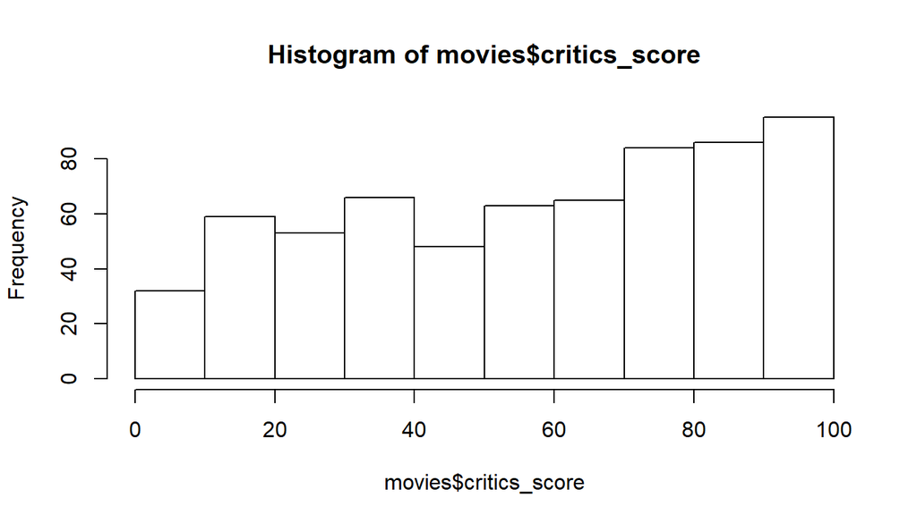

```r
hist(movies$critics_score)
```

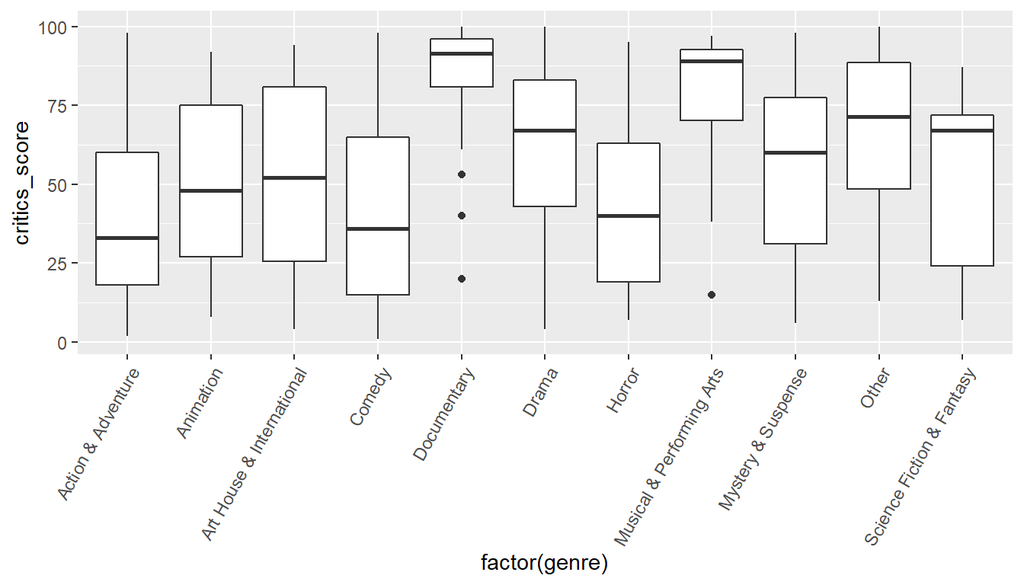

```r
ggplot(movies, aes(x=factor(genre), y=critics_score))+
  geom_boxplot() +
  theme(axis.text.x = element_text(angle = 60, hjust = 1))
```

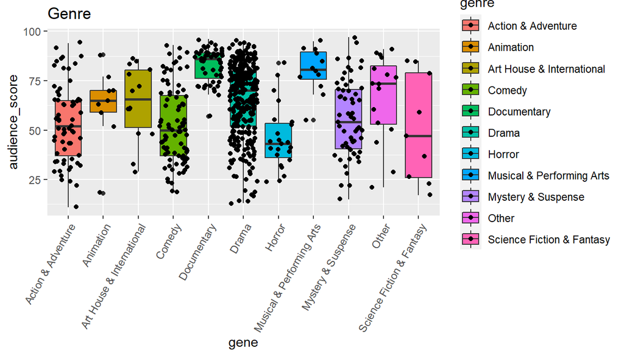

```r
qplot(genre,audience_score,data=movies,geom = c("boxplot","jitter"),
      fill=genre, main= "Genre", xlab = "gene", ylab = "audience_score")+
      theme(axis.text.x = element_text(angle = 60, hjust = 1))
```

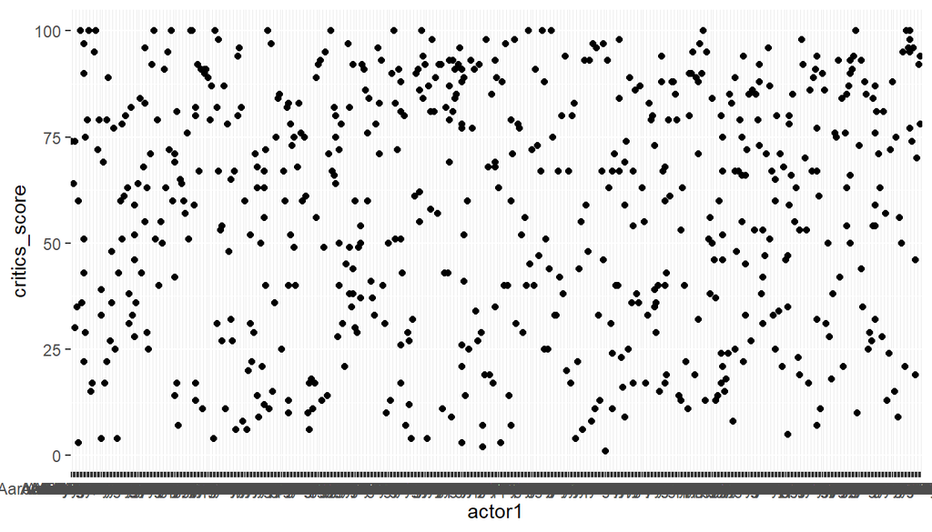

```r
ggplot(movies, aes(x=actor1, y=critics_score))+
  geom_point()
```

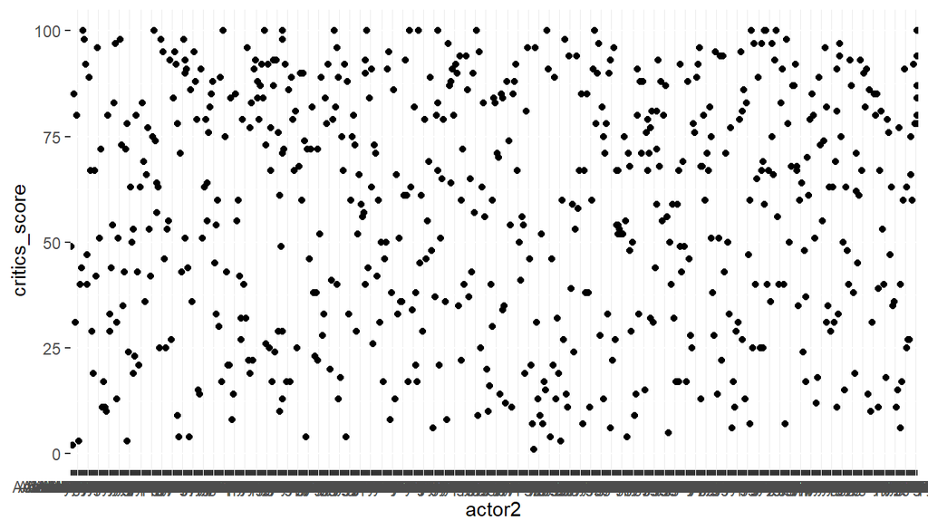

```r
ggplot(movies, aes(x=actor2, y=critics_score))+
  geom_point()
```

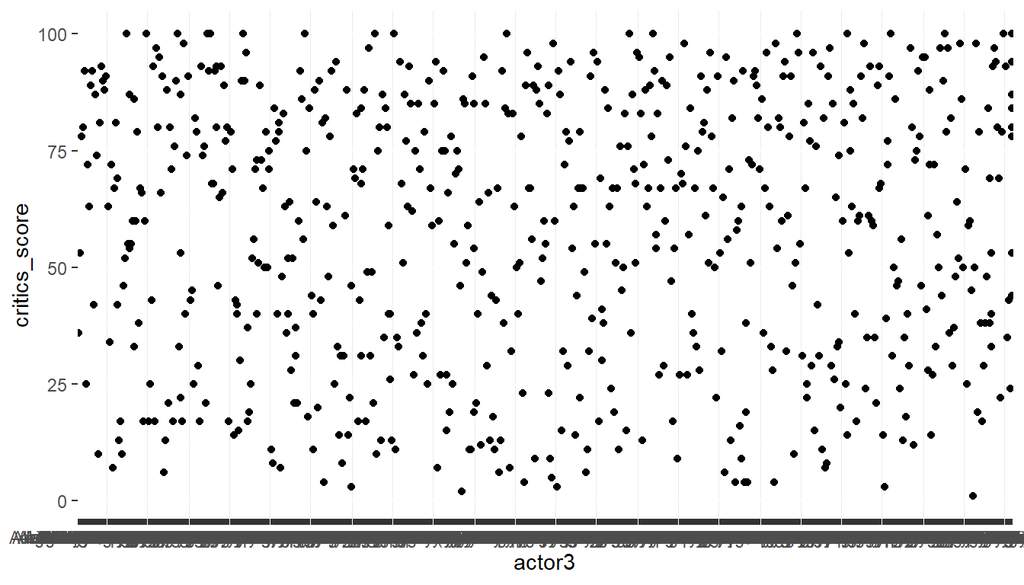

```r
ggplot(movies, aes(x=actor3, y=critics_score))+
  geom_point()
```

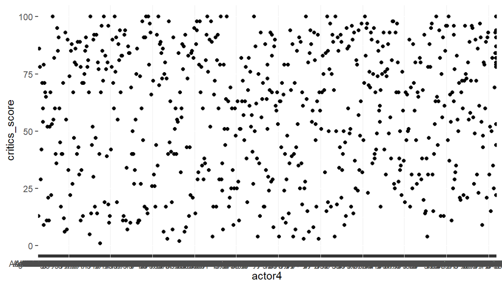

```r
ggplot(movies, aes(x=actor4, y=critics_score))+
  geom_point()
```

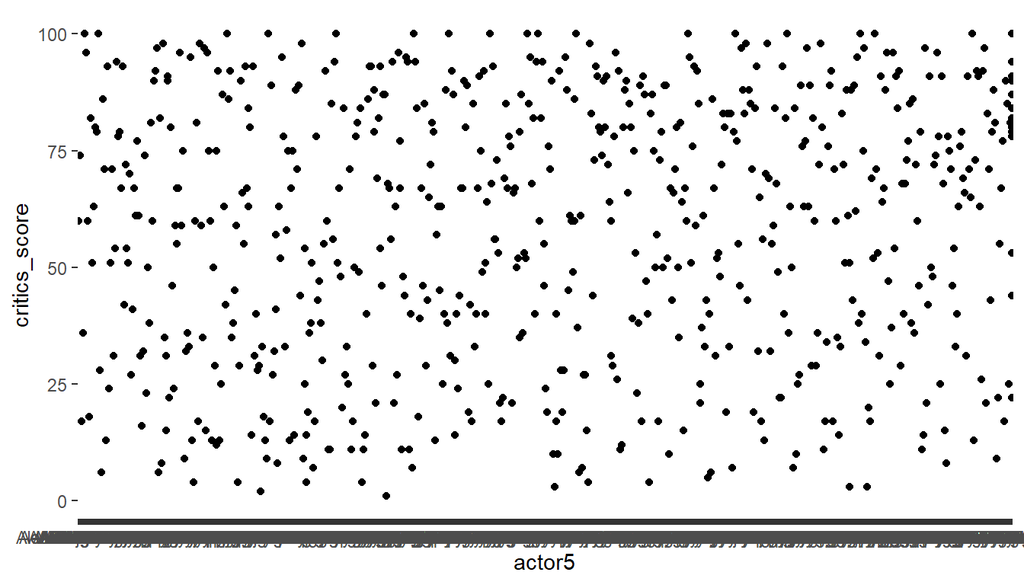

```r
ggplot(movies, aes(x=actor5, y=critics_score))+
  geom_point()
```

There is no linear association between critic scores and the actor variables.

Does being nominated and/or winning the best actor/actress/director and /or winning best picture associate with critic scores?

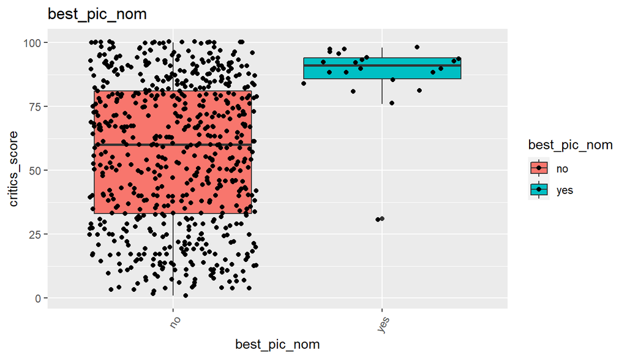

```r
qplot(best_pic_nom,critics_score,data=movies,geom = c("boxplot","jitter"),
      fill=best_pic_nom, main= "best_pic_nom", xlab = "best_pic_nom", ylab = "critics_score")+
      theme(axis.text.x = element_text(angle = 60, hjust = 1))
```

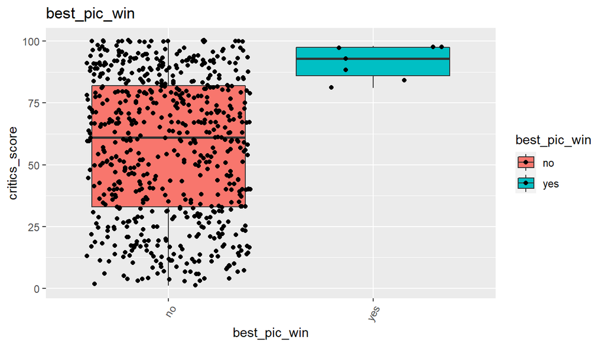

```r
qplot(best_pic_win,critics_score,data=movies,geom = c("boxplot","jitter"),
      fill=best_pic_win, main= "best_pic_win", xlab = "best_pic_win", ylab = "critics_score")+
      theme(axis.text.x = element_text(angle = 60, hjust = 1))
```

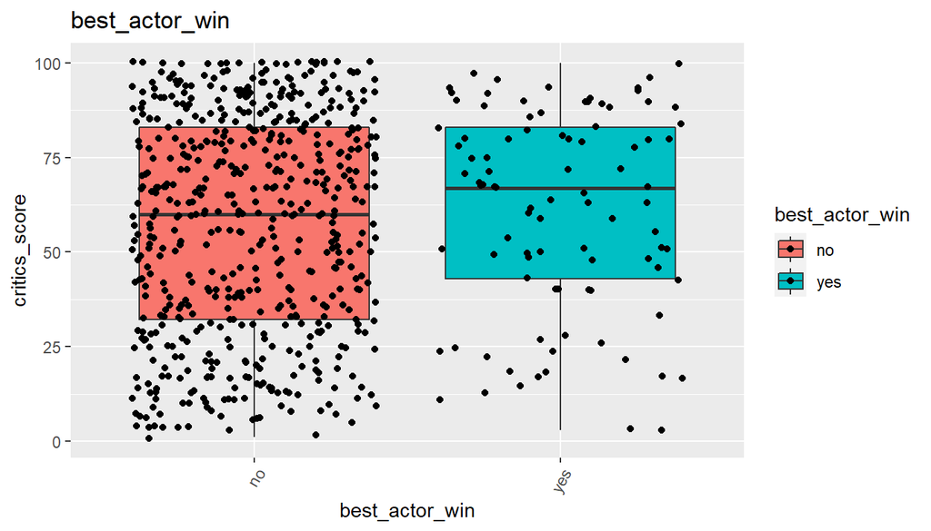

```r
qplot(best_actor_win,critics_score,data=movies,geom = c("boxplot","jitter"),
      fill=best_actor_win, main= "best_actor_win", xlab = "best_actor_win", ylab = "critics_score")+
      theme(axis.text.x = element_text(angle = 60, hjust = 1))
```

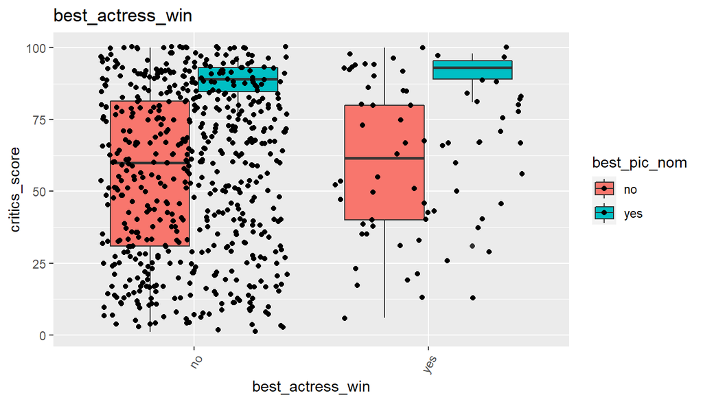

```r
qplot(best_actress_win,critics_score,data=movies,geom = c("boxplot","jitter"),
      fill=best_pic_nom, main= "best_actress_win", xlab = "best_actress_win", ylab = "critics_score")+
      theme(axis.text.x = element_text(angle = 60, hjust = 1))
```

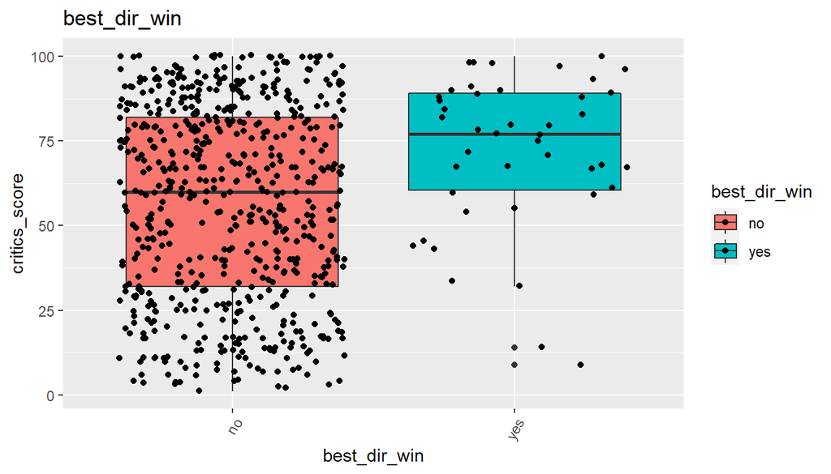

```r
qplot(best_dir_win,critics_score,data=movies,geom = c("boxplot","jitter"),
      fill=best_dir_win, main= "best_dir_win", xlab = "best_dir_win", ylab = "critics_score")+
      theme(axis.text.x = element_text(angle = 60, hjust = 1))
```

It looks like most critics are likely to hold contrarian opinions about whether a movie is good or not,but they mostly agree whether a movie is good or not.Quite a few outliers as a result.

## Part 4: Modeling

```r
m_full <- lm(critics_score ~  genre + imdb_rating +imdb_num_votes+audience_score+  audience_rating+director, data =movies)
summary(m_full)
```

```
##
## Call:
## lm(formula = critics_score ~ genre + imdb_rating + imdb_num_votes +
##     audience_score + audience_rating + director, data = movies)
##
## Residuals:
##    Min     1Q Median     3Q    Max
## -40.92   0.00   0.00   0.00  40.92
##
## Coefficients:
##                                       Estimate Std. Error t value Pr(>|t|)
## (Intercept)                         -3.455e+01  1.312e+01  -2.634  0.00973 **
## genreAnimation                      -3.635e-01  1.584e+01  -0.023  0.98174
## genreArt House & International      -1.522e+01  1.208e+01  -1.260  0.21053
## genreComedy                          6.910e+00  7.299e+00   0.947  0.34597
## genreDocumentary                    -9.044e+00  1.532e+01  -0.591  0.55614
## genreDrama                           9.974e-01  6.083e+00   0.164  0.87007
## genreHorror                          6.029e+00  1.377e+01   0.438  0.66239
## genreMusical & Performing Arts       6.211e+00  1.418e+01   0.438  0.66225
## genreMystery & Suspense             -1.014e+00  7.798e+00  -0.130  0.89676
## genreOther                           8.605e+00  1.043e+01   0.825  0.41115
## genreScience Fiction & Fantasy       7.267e+00  1.701e+01   0.427  0.67014
## imdb_rating                          8.618e+00  4.699e+00   1.834  0.06954 .
## imdb_num_votes                      -5.212e-06  1.604e-05  -0.325  0.74581
## audience_score                       6.215e-01  2.397e-01   2.593  0.01089 *
## audience_ratingUpright               1.022e+00  6.245e+00   0.164  0.87039
## directorAbel Ferrara                 1.243e+01  2.419e+01   0.514  0.60862
## directorAdam McKay                   1.668e+01  2.448e+01   0.681  0.49731
## directorAdam Salky                   2.159e+01  2.537e+01   0.851  0.39659
## directorAdam Shankman                7.384e+00  2.597e+01   0.284  0.77670
## directorAdam Simon                  -4.681e+00  2.419e+01  -0.193  0.84695
## directorAdrian Grenier               2.039e+01  2.676e+01   0.762  0.44790
## directorAgnes Varda                  1.565e+01  2.758e+01   0.567  0.57178
## directorAgnieszka Holland           -7.543e+00  2.260e+01  -0.334  0.73918
## directorAlan Alda                    1.515e+01  2.258e+01   0.671  0.50389
## directorAlejandro Agresti           -3.586e+01  2.388e+01  -1.501  0.13630
## directorAlejandro Gonzalez Inarritu -6.319e+00  2.500e+01  -0.253  0.80098
## directorAlejandro Jodorowsky        -2.829e+00  2.556e+01  -0.111  0.91210
## directorAlex Chandon                -9.104e-01  2.623e+01  -0.035  0.97238
## directorAlex Gregory                -1.918e+01  2.554e+01  -0.751  0.45430
```

[output cut: 509 more lines]

```
## directorWilliam Sachs               -1.168e+00  2.583e+01  -0.045  0.96404
## directorWilliam Shatner             -5.686e+00  2.529e+01  -0.225  0.82256
## directorWim Wenders                  5.676e+00  2.832e+01   0.200  0.84155
## directorWolfgang Reitherman         -3.190e+01  2.619e+01  -1.218  0.22598
## directorWoody Allen                 -3.059e+00  2.128e+01  -0.144  0.88600
## directorYoshiaki Kawajiri           -1.502e+01  2.661e+01  -0.565  0.57354
## directorYurek Bogayevicz             1.854e+01  2.387e+01   0.777  0.43894
## directorYves Simoneau                1.464e+01  2.486e+01   0.589  0.55724
## ---
## Signif. codes:  0 '***' 0.001 '**' 0.01 '*' 0.05 '.' 0.1 ' ' 1
##
## Residual standard error: 15.68 on 103 degrees of freedom
##   (2 observations deleted due to missingness)
## Multiple R-squared:  0.9515, Adjusted R-squared:  0.6951
## F-statistic:  3.71 on 545 and 103 DF,  p-value: 8.003e-14
```

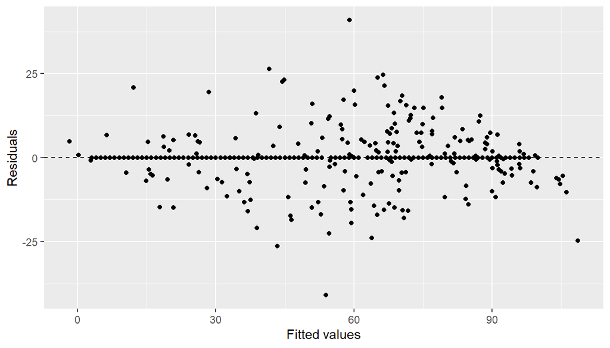

```r
ggplot(data = m_full, aes(x = .fitted, y = .resid)) +
  geom_point() +
  geom_hline(yintercept = 0, linetype = "dashed") +
  xlab("Fitted values") +
  ylab("Residuals")
```

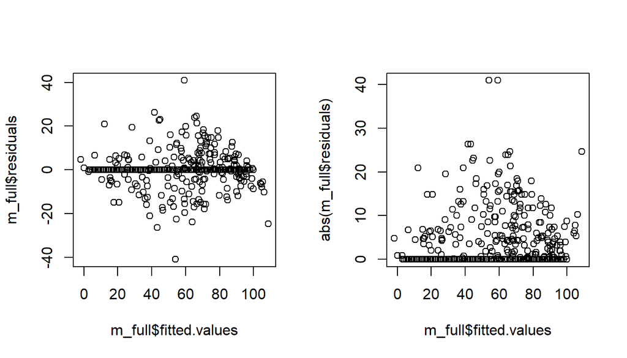

```r
par(mfrow = c(1, 2))
plot(m_full$fitted.values, m_full$residuals)
plot(m_full$fitted.values, abs(m_full$residuals))
```

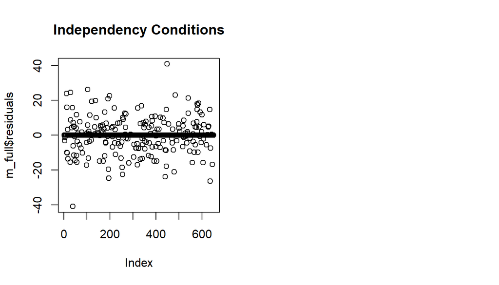

```r
plot(m_full$residuals, main="Independency Conditions")
```

Adjusted R-squared is 0.6951 Condition met – the plot shows residuals being randomly scattered around zero.

```r
anova(m_full)
```

```
## Analysis of Variance Table
##
## Response: critics_score
##                  Df Sum Sq Mean Sq  F value    Pr(>F)
## genre            10 101705   10170  41.3411 < 2.2e-16 ***
## imdb_rating       1 211818  211818 861.0021 < 2.2e-16 ***
## imdb_num_votes    1    317     317   1.2898 0.2587199
## audience_score    1   3158    3158  12.8349 0.0005213 ***
## audience_rating   1    150     150   0.6109 0.4362414
## director        531 180289     340   1.3801 0.0225747 *
## Residuals       103  25339     246
## ---
## Signif. codes:  0 '***' 0.001 '**' 0.01 '*' 0.05 '.' 0.1 ' ' 1
```

There are certain variables like imdb_num_votes and audience_rating which are not significant in predicting critic scores,based on their p values. An interesting observation is that the director value has a significant effect on critics

Linearity condition is met for the significant variables.

```r
m_comp=lm(critics_score~genre+imdb_rating+audience_score+director,data=movies)
summary(m_comp)
```

```
##
## Call:
## lm(formula = critics_score ~ genre + imdb_rating + audience_score +
##     director, data = movies)
##
## Residuals:
##    Min     1Q Median     3Q    Max
## -41.07   0.00   0.00   0.00  41.07
##
## Coefficients:
##                                       Estimate Std. Error t value Pr(>|t|)
## (Intercept)                         -34.635437  12.668371  -2.734 0.007345 **
## genreAnimation                       -0.230280  15.658787  -0.015 0.988295
## genreArt House & International      -14.785495  11.882481  -1.244 0.216156
## genreComedy                           6.950776   7.229716   0.961 0.338551
## genreDocumentary                     -8.444935  15.076022  -0.560 0.576566
## genreDrama                            1.185860   6.001639   0.198 0.843748
## genreHorror                           6.148955  13.562547   0.453 0.651212
## genreMusical & Performing Arts        7.623798  13.440666   0.567 0.571776
## genreMystery & Suspense              -0.732052   7.669994  -0.095 0.924144
## genreOther                            8.402246  10.274174   0.818 0.415322
## genreScience Fiction & Fantasy        7.544266  16.757336   0.450 0.653490
## imdb_rating                           8.101127   4.407953   1.838 0.068913 .
## audience_score                        0.651987   0.189405   3.442 0.000829 ***
## directorAbel Ferrara                 14.647037  23.090837   0.634 0.527250
## directorAdam McKay                   17.744248  23.687067   0.749 0.455465
## directorAdam Salky                   23.485376  24.398399   0.963 0.337971
## directorAdam Shankman                 7.505100  25.634397   0.293 0.770272
## directorAdam Simon                   -3.705033  23.812386  -0.156 0.876653
## directorAdrian Grenier               21.845276  25.819973   0.846 0.399443
## directorAgnes Varda                  17.440944  26.615377   0.655 0.513710
## directorAgnieszka Holland            -5.427590  21.458285  -0.253 0.800812
## directorAlan Alda                    17.157084  21.525437   0.797 0.427214
## directorAlejandro Agresti           -34.233122  23.170271  -1.477 0.142546
## directorAlejandro Gonzalez Inarritu  -4.999964  24.328071  -0.206 0.837562
## directorAlejandro Jodorowsky         -0.651951  24.248569  -0.027 0.978602
## directorAlex Chandon                  0.577342  25.469048   0.023 0.981958
## directorAlex Gregory                -17.273785  24.457321  -0.706 0.481577
## directorAlex Smith                   28.345283  23.938483   1.184 0.239052
## directorAlexandre Aja               -29.546917  24.480178  -1.207 0.230155
```

[output cut: 507 more lines]

```
## directorWilliam Sachs                -0.404317  25.507139  -0.016 0.987383
## directorWilliam Shatner              -3.758333  24.420044  -0.154 0.877981
## directorWim Wenders                   6.822032  27.756652   0.246 0.806332
## directorWolfgang Reitherman         -29.744057  25.041716  -1.188 0.237600
## directorWoody Allen                  -1.035558  20.024604  -0.052 0.958855
## directorYoshiaki Kawajiri           -12.624217  25.160114  -0.502 0.616890
## directorYurek Bogayevicz             20.117880  23.014689   0.874 0.384041
## directorYves Simoneau                16.365773  23.996134   0.682 0.496730
## ---
## Signif. codes:  0 '***' 0.001 '**' 0.01 '*' 0.05 '.' 0.1 ' ' 1
##
## Residual standard error: 15.54 on 105 degrees of freedom
##   (2 observations deleted due to missingness)
## Multiple R-squared:  0.9515, Adjusted R-squared:  0.7005
## F-statistic: 3.791 on 543 and 105 DF,  p-value: 2.192e-14
```

Adjusted R-squared increased to 0.7005 which shows better effectiveness of the model in predicting critic scores.

## Part 5: Prediction

We will be predicting the critic score for the mystery movie Die Hard 2.The values for the predictors were obtained from the sources mentioned in the codebook: IMDb and Rotten Tomatoes; and from common sense.

```r
genre <- "Mystery & Suspense"
imdb_rating <- 7.1
audience_score <- 70
director <- "Renny Harlin"
critics_score <- 69
TestA <- data.frame (genre, imdb_rating,audience_score,critics_score, director)
prediction_DH2 <- predict(m_comp,newdata=TestA, interval="confidence")
myPrediction <- round(predict(m_comp, TestA), digits = 0)
c(myPrediction, TestA$critics_score) #compare fitted and observed values
```

```
##  1
## 65 69
```

```r
prediction_DH2
```

```
##        fit      lwr      upr
## 1 65.10004 48.17126 82.02881
```

The predicted critic score is 65 which is close to the actual 69,and is contained in the 95% confidence interval

## Part 6: Conclusion

Explanatory data analysis proved to be a valuable process in identifying what feature matters most to achieve better results. The model developed predicted the critic score for the movie. The first observation is that we have limited amount of data. Data from different geners equally distributed would help to train the model more accurately. Information such as gross estimated and actual earnings by movies is missing and could be helpful to have more insights for following critic feedback .